# Lasso and Elastic Net

7/17/2024

# Data Import and Cleaning

First, load the dataset; clean up names as needed; and convert factors to, well, factors.

Quick data descriptions; because of the length of the output, we don’t execute this command here, but encourage you to!

Next we remove missing values and reorder predictors (environmental variables first, confounders second). In keeping with standard practice, we’ll ln-transform the environmental exposures and the outcome. This is the dataset we’ll use to illustrate variable selection methods.

```
##  [1] "log_telomean" "lbx074la"     "lbx099la"     "lbx118la"     "lbx138la"
##  [6] "lbx153la"     "lbx170la"     "lbx180la"     "lbx187la"     "lbxd03la"
## [11] "lbxd05la"     "lbxd07la"     "lbxf03la"     "lbxf04la"     "lbxf05la"
## [16] "lbxf08la"     "lbxpcbla"     "lbxhxcla"     "lbx194la"     "lbxwbcsi"
## [21] "lbxlypct"     "lbxmopct"     "lbxnepct"     "lbxeopct"     "lbxbapct"
## [26] "bmi_cat3"     "edu_cat"      "race_cat"     "male"         "ln_lbxcot"
## [31] "age_cent"     "age_sq"
```

```
## [1] 1003   32
```

Model fitting methods aren’t “tidy-compliant” yet, so we’ll focus on creating the relevant matrices and vectors.

Let’s take a quick look at our design matrix.

```
## [1] 1003   36
```

```
##  [1] "lbx074la"  "lbx099la"  "lbx118la"  "lbx138la"  "lbx153la"  "lbx170la"
##  [7] "lbx180la"  "lbx187la"  "lbxd03la"  "lbxd05la"  "lbxd07la"  "lbxf03la"
## [13] "lbxf04la"  "lbxf05la"  "lbxf08la"  "lbxpcbla"  "lbxhxcla"  "lbx194la"
## [19] "lbxwbcsi"  "lbxlypct"  "lbxmopct"  "lbxnepct"  "lbxeopct"  "lbxbapct"
## [25] "bmi_cat32" "bmi_cat33" "edu_cat2"  "edu_cat3"  "edu_cat4"  "race_cat2"
## [31] "race_cat3" "race_cat4" "male1"     "ln_lbxcot" "age_cent"  "age_sq"
```

It’s helpful to note that chemical exposures appear in columns 1 to 18, and more traditional confounders appear in columns 19 to 36.

## Data Visualization

A few quick plots to examine associations between exposures and the outcome. First, chemical exposures:

g: grid lines; p: points; smooth: Loess

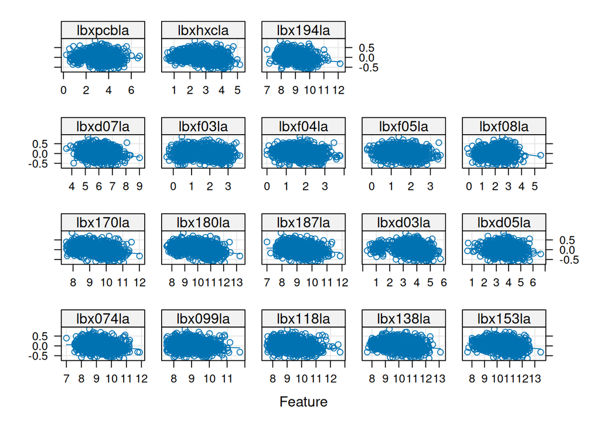

Next, remaining confounders:

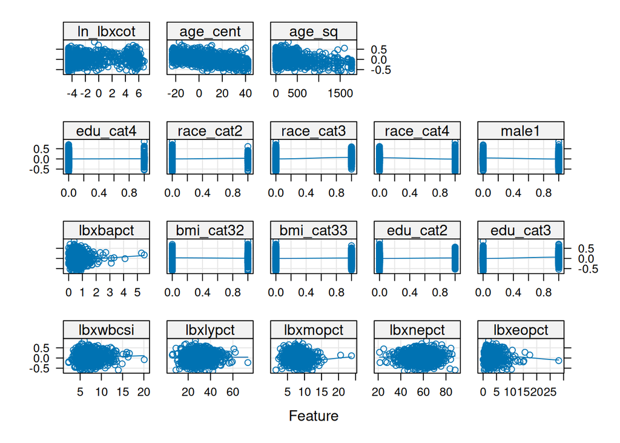

# Lasso w/ CV

We’ll begin by looking at the lasso applied to the complete design matrix. In the following, we’ll use CV to identify tuning parameters; this is a random process, so we’ll set the seed to ensure reproducibility. First we’ll use a specified grid of tuning parameter values and fit the lasso model for each.

We can explore the results using a coefficient path plot or numerically.

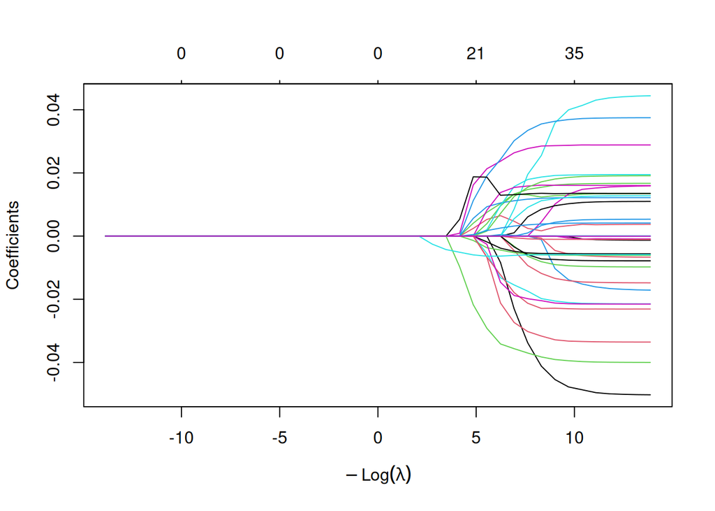

```
## (Intercept)    lbx074la    lbx099la    lbx118la    lbx138la    lbx153la
##   0.0249817   0.0000000   0.0000000   0.0000000   0.0000000   0.0000000
##    lbx170la    lbx180la    lbx187la    lbxd03la    lbxd05la    lbxd07la
##   0.0000000   0.0000000   0.0000000   0.0000000   0.0000000   0.0000000
##    lbxf03la    lbxf04la    lbxf05la    lbxf08la    lbxpcbla    lbxhxcla
##   0.0000000   0.0000000   0.0000000   0.0000000   0.0000000   0.0000000
##    lbx194la    lbxwbcsi    lbxlypct    lbxmopct    lbxnepct    lbxeopct
##   0.0000000   0.0000000   0.0000000   0.0000000   0.0000000   0.0000000
##    lbxbapct   bmi_cat32   bmi_cat33    edu_cat2    edu_cat3    edu_cat4
##   0.0000000   0.0000000   0.0000000   0.0000000   0.0000000   0.0000000
##   race_cat2   race_cat3   race_cat4       male1   ln_lbxcot    age_cent
##   0.0000000   0.0000000   0.0000000   0.0000000   0.0000000   0.0000000
##      age_sq
##   0.0000000
```

Some built-in functions will conduct a cross-validation analysis and identify the “best” tuning parameter.

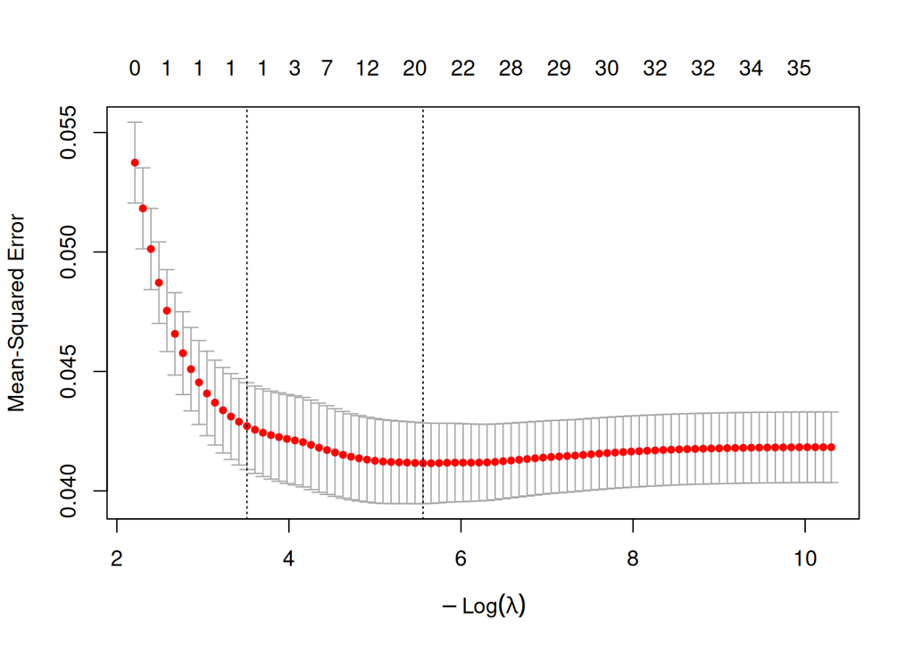

```
## 37 x 1 sparse Matrix of class "dgCMatrix"
##              lambda.1se
## (Intercept)  0.04796516
## lbx074la     .
## lbx099la     .
## lbx118la     .
## lbx138la     .
## lbx153la     .
## lbx170la     .
## lbx180la     .
## lbx187la     .
## lbxd03la     .
## lbxd05la     .
## lbxd07la     .
## lbxf03la     .
## lbxf04la     .
## lbxf05la     .
## lbxf08la     .
## lbxpcbla     .
## lbxhxcla     .
## lbx194la     .
## lbxwbcsi     .
## lbxlypct     .
## lbxmopct     .
## lbxnepct     .
## lbxeopct     .
## lbxbapct     .
## bmi_cat32    .
## bmi_cat33    .
## edu_cat2     .
## edu_cat3     .
## edu_cat4     .
## race_cat2    .
## race_cat3    .
## race_cat4    .
## male1        .
## ln_lbxcot    .
## age_cent    -0.00434132
## age_sq       .
```

```
## [1] 0.003850403
```

Optional arguments to `glmnet` can be useful – in particular, `weights` can be used in the context of the adaptive lasso and `penalty.factor` can separate penalized variables from confounders.

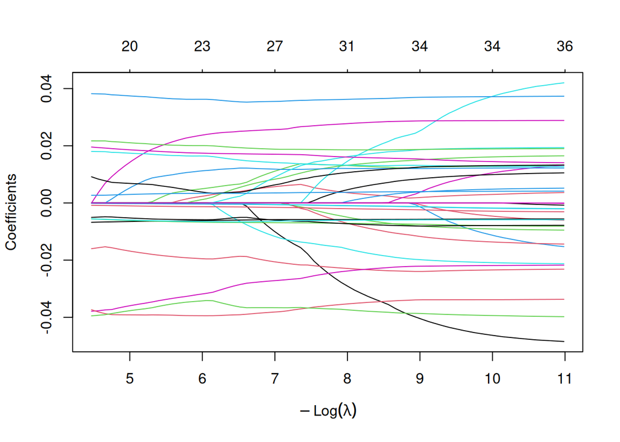

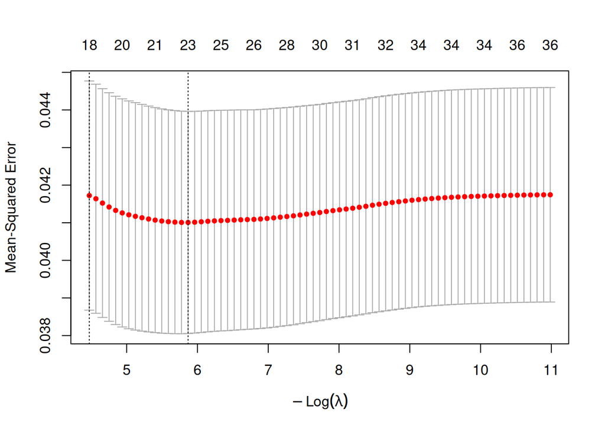

```
## [1] 0.002829472
```

Let’s examine the model with the best CV score.

```
## 37 x 1 sparse Matrix of class "dgCMatrix"
##                        s0
## (Intercept)  9.924198e-02
## lbx074la     .
## lbx099la     2.332399e-03
## lbx118la     4.110223e-03
## lbx138la     .
## lbx153la     .
## lbx170la     .
## lbx180la     .
## lbx187la     .
## lbxd03la     .
## lbxd05la     .
## lbxd07la     .
## lbxf03la     2.309937e-02
## lbxf04la     .
## lbxf05la     .
## lbxf08la     5.545589e-04
## lbxpcbla     1.092127e-02
## lbxhxcla     .
## lbx194la     .
## lbxwbcsi    -6.214042e-03
## lbxlypct    -1.110407e-03
## lbxmopct    -6.489905e-03
## lbxnepct    -2.050592e-04
## lbxeopct     7.410190e-05
## lbxbapct     1.764742e-02
## bmi_cat32   -5.851311e-03
## bmi_cat33   -1.931380e-02
## edu_cat2     2.005261e-02
## edu_cat3     3.623590e-02
## edu_cat4     1.637938e-02
## race_cat2   -3.239001e-02
## race_cat3    4.203572e-03
## race_cat4   -3.946853e-02
## male1       -3.455470e-02
## ln_lbxcot    3.353031e-03
## age_cent    -6.470375e-03
## age_sq      -1.112578e-05
```

```
## [1] 24
```

```
##  [1] "(Intercept)" "lbx099la"    "lbx118la"    "lbxf03la"    "lbxf08la"
##  [6] "lbxpcbla"    "lbxwbcsi"    "lbxlypct"    "lbxmopct"    "lbxnepct"
## [11] "lbxeopct"    "lbxbapct"    "bmi_cat32"   "bmi_cat33"   "edu_cat2"
## [16] "edu_cat3"    "edu_cat4"    "race_cat2"   "race_cat3"   "race_cat4"
## [21] "male1"       "ln_lbxcot"   "age_cent"    "age_sq"
```

```
## [1] 0.03933876
```

The final code chunk saves the best lasso coefficients for later use.

# Elastic Net w/ CV

`glmnet` implements the elastic net – we’ve set `alpha` to 1 to focus on lasso regression, but could choose `alpha` between 0 and 1. In the following, we can tune alpha and lambda simultaneously.

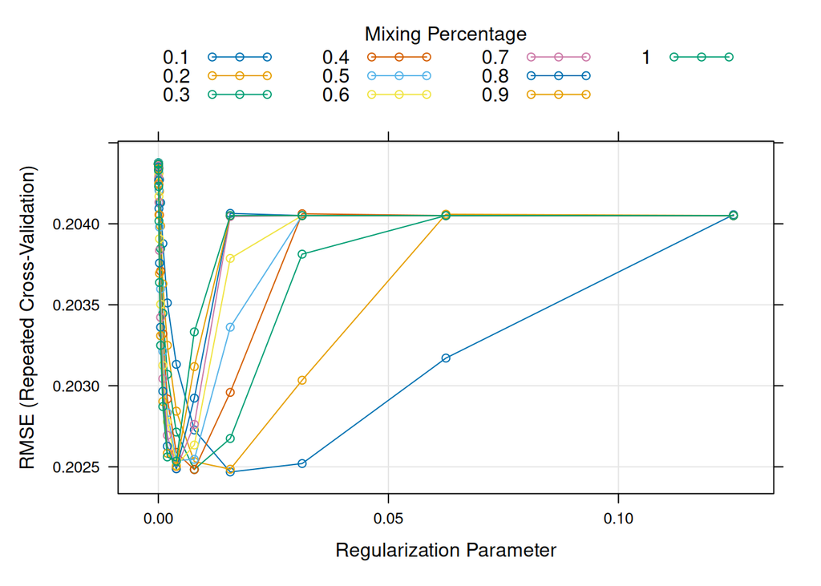

For the optimal `alpha` value, we identify a best lambda and explore the results.

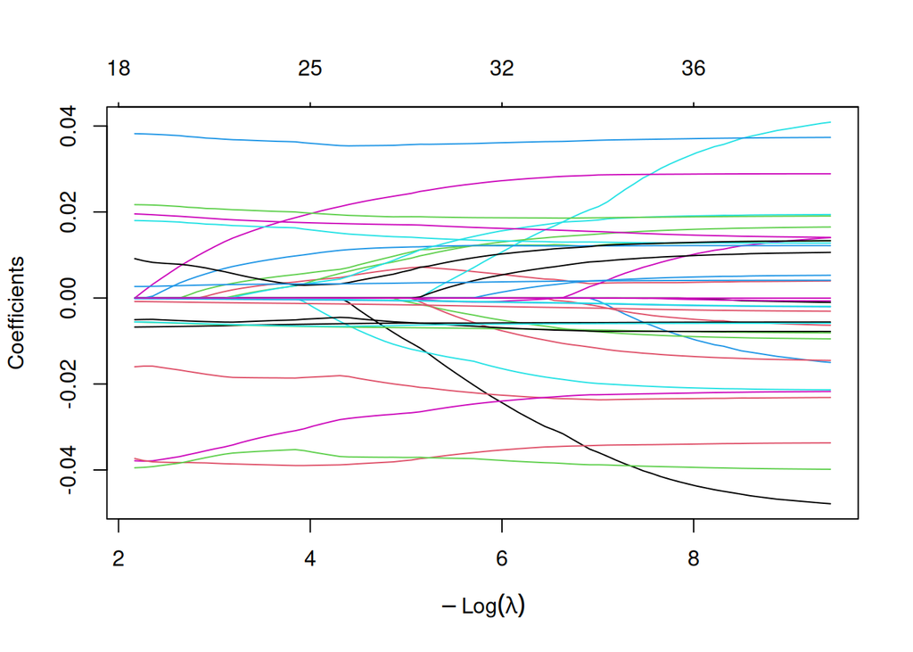

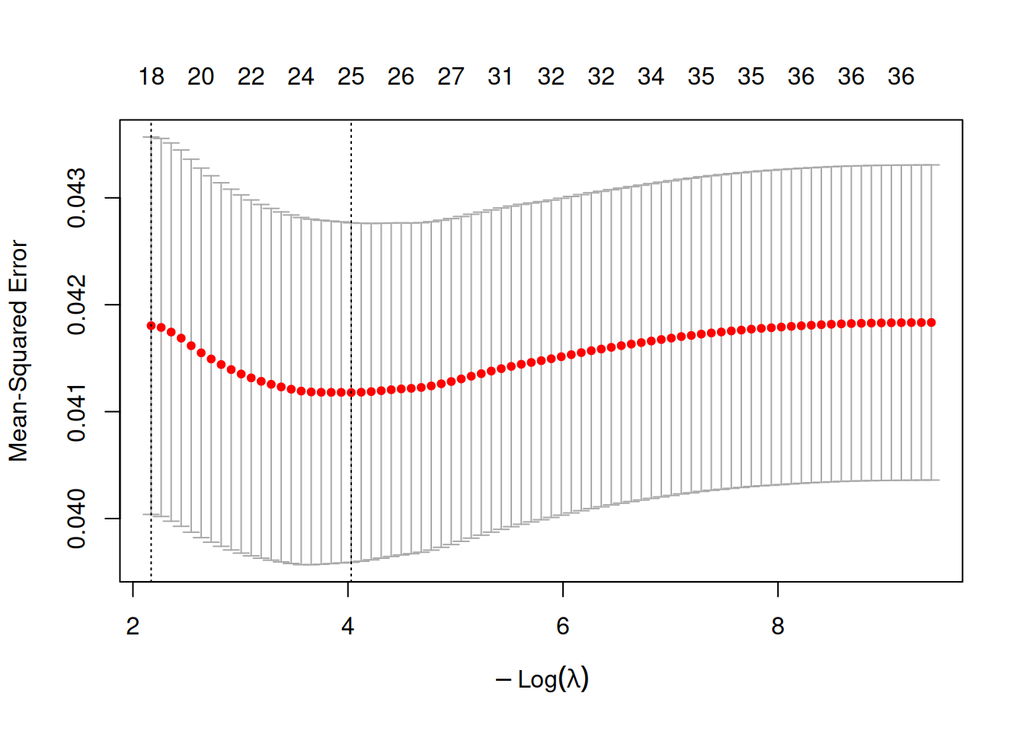

```
## [1] 0.01776991
```

```
## 37 x 1 sparse Matrix of class "dgCMatrix"
##                        s0
## (Intercept)  6.473262e-02
## lbx074la     .
## lbx099la     4.140880e-03
## lbx118la     5.930860e-03
## lbx138la     .
## lbx153la     .
## lbx170la     .
## lbx180la     .
## lbx187la     .
## lbxd03la     .
## lbxd05la     .
## lbxd07la    -2.157591e-03
## lbxf03la     1.973795e-02
## lbxf04la     .
## lbxf05la     .
## lbxf08la     3.989616e-03
## lbxpcbla     1.031686e-02
## lbxhxcla     3.619584e-03
## lbx194la     .
## lbxwbcsi    -6.076710e-03
## lbxlypct    -1.073345e-03
## lbxmopct    -6.414261e-03
## lbxnepct    -1.918824e-04
## lbxeopct     3.039335e-06
## lbxbapct     1.771860e-02
## bmi_cat32   -4.765236e-03
## bmi_cat33   -1.832670e-02
## edu_cat2     1.967472e-02
## edu_cat3     3.591101e-02
## edu_cat4     1.576450e-02
## race_cat2   -2.970090e-02
## race_cat3    3.177860e-03
## race_cat4   -3.883270e-02
## male1       -3.592855e-02
## ln_lbxcot    3.274186e-03
## age_cent    -6.564323e-03
## age_sq      -1.075483e-05
```

```
## [1] 26
```

```
##  [1] "(Intercept)" "lbx099la"    "lbx118la"    "lbxd07la"    "lbxf03la"
##  [6] "lbxf08la"    "lbxpcbla"    "lbxhxcla"    "lbxwbcsi"    "lbxlypct"
## [11] "lbxmopct"    "lbxnepct"    "lbxeopct"    "lbxbapct"    "bmi_cat32"
## [16] "bmi_cat33"   "edu_cat2"    "edu_cat3"    "edu_cat4"    "race_cat2"
## [21] "race_cat3"   "race_cat4"   "male1"       "ln_lbxcot"   "age_cent"
## [26] "age_sq"
```

```
## [1] 0.03928275
```

The final code chunk saves the best lasso coefficients for later use.

# Compare Lasso and Elastic Net

The table below compares the lasso and elastic net in terms of MSE.

| Lasso Lambda | Lasso MSE | Elastic Lambda | Elastic Net MSE |
| --- | --- | --- | --- |
| 0.0028295 | 0.0393388 | 0.0177699 | 0.0392828 |

# OLS from Lasso Results

We can compare the results of the lasso fit to an OLS fit using the selected variables

```
## # A tibble: 23 × 3
##    term          lasso        ols
##    <chr>         <dbl>      <dbl>
##  1 lbx099la  0.00233    0.0180
##  2 lbx118la  0.00411   -0.0783
##  3 lbxf03la  0.0231    -0.00355
##  4 lbxf08la  0.000555  NA
##  5 lbxpcbla  0.0109     0.0198
##  6 lbxwbcsi -0.00621    0.0000914
##  7 lbxlypct -0.00111    0.00859
##  8 lbxmopct -0.00649    0.00106
##  9 lbxnepct -0.000205   0.00846
## 10 lbxeopct  0.0000741  0.00599
## # ℹ 13 more rows
```

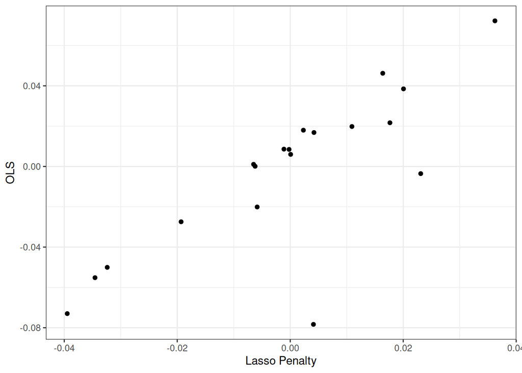